# Week 5

More about pointers and memory, and some new data structures!

Aryaman Arora

November 5, 2016

# Pointers, continued

An `unsigned int` only uses positive numbers (and 0). `*=` multiples the number by some factor. Other forms exist, like `/=`. `sscanf` basically “analyzes” a line.

```c
#include <stdio.h>

int main(void)
{
    // initialize two addresses of ints
    int* x;
    int* y;

    // give me some memory for x
    x = malloc(sizeof(int));

    *x = 42;
    *y = 13;

    y = x;
    *y = 13;
}
```

Behold, `scanf`! This is the actual `GetString()`, `GetInt`, etc.

```c
int x;
scanf("%i", &x);
```

Same for:

```c
char* x;
scanf("%s", x)
```

Here, `x` is already a pointer, so we don’t need `&x`.

But… this will cause a segmentation fault! We might alter something that we don’t have access to in memory.

Even if we use, say `char x[16]`, we might need more memory. So, we, might use `char x[1000]`. But what if we need more? This can get out of hand quickly, and is wasteful.

This is where `realloc` comes in, and good ol’ `cs50.h`. There’s a lot hidden in there. Basically, the library just adds memory iteratively as it needs it.

[Official Notes](http://cdn.cs50.net/2015/fall/lectures/5/m/notes5m/notes5m.html)

# Memory

All the code I’ve written so far is *buggy*. I’ve been getting memory but not `free()`ing it (until pset4)! This is not a big deal since all the programs that we’ve made have been small, but this can slow down the computer in bigger programs.

How do you find memory leaks? `valgrind`!

```
valgrind --leak-check=full ./program
```

Here’s an example of a buggy program:

```c
int f(void)
{
    int* x = malloc(10 * sizeof(int));
    // uh oh ... zero-indexing!
    x[10] = 0;
    // hey, we aren't freeing x!
}

int main(void)
{
    f();
    return 0;
}
```

Hint: `valgrind` will help you.

Fixed:

```c
int f(void)
{
    int* x = malloc(10 * sizeof(int));
    x[9] = 0; // allowed
    free(x); // no memory leaks
}

int main(void)
{
    f();
    return 0;
}
```

[figure not shown]

xkcd Pointers

# Data Structures

Arrays are good in C for storing data, but *you can’t change the size of the array* (unlike some higher-level languages).

Instead, we can start making our own data structures. This is where **linked lists** come in.

```
graph LR
subgraph one
    first --- ptr1
end
subgraph two
    second --- ptr2
end
subgraph three
    third --- ptr3
end
head --> first
ptr1 --> second
ptr2 --> third
ptr3 --> NULL
```

Let’s start with the first rectangle. How would we implement this? Structs!

```c
typedef struct node
{
    int n;
    struct node* next;
}
node;
```

Here, we’re recursively defining a node. (The reason we’re using `struct node*` is because C reads top to bottom and left to right, and it doesn’t node what a `node` is until it reads the whole thing).

This is amazing! Some cons though: - thrice the size (pointer (8 bytes) + `int`) - traverse list one by one; give up bracket `[]` notation

## Stacks and Queues

(Trust me, you’ll need this) Think about stacks of trays; this is a LIFO (last in first out) data structure.

Further, there are queues, which are FIFO (first in first out).

Let’s look at linked lists agains: what’s so great about them? **They can be dynamically resized**.

## Searching Linked Lists

```c
typedef struct node
{
    int n;
    struct node* next;
}
node;

// make some list...

bool search(int n, node* list)
{
    node* ptr = list;
    while (ptr != NULL) // NULL demarcates end of list
    {
        if (ptr->n == n) // if this matches our number
        {
            return true;
        }
        ptr = ptr -> next // go to next node
    }
    return false;
}
```

## Stacks

```c
typedef struct
{
    int numbers[CAPACITY]; // array of some numbers
    int size; // size?
}
stack;
```

Stacks have two main functions: `push` and `pop`. **`push`** adds something to the stack at the leftmost part and increments size.

**`pop`** removes the last added value ($\text{size} - 1$). Actually, we reduce size, but we don’t remove anything; the computer *just forgets*.

What if you go beyond `CAPACITY`? Whelp, nothing you can do, since you can’t resize this array. Here’s a better implementation:

```c
typedef struct
{
        int* numbers;
        int size;
}
stack;
```

Here, we just store the address of the first number. When invoking this, however, you will need `malloc`.

## Queues

```c
typedef struct
{
        int front;
        int numbers[CAPACITY]
        int size;
}
queue;
```

**enqueue**

add to the leftmost available bit

**dequeue**

remove first value, decrement `size`, increment `front`

The `%` (modulo) operator helps to implement circularity in the queue.

Here’s a dynamic implementation:

```c
typedef struct
{
        int front;
        int* numbers;
        int size;
}
queue;
```

# Memory and Heaps

When you are calling a function, it is added to the stack; it gets a slice of its own memory.

But guess what; there’s more memory at the top of the memory! This is the heap. When you call `malloc` you get some memory from the heap.

But isn’t this dangerous? The stack and heap might clash in a computer with finite memory.

## Buffer Overflow

```c
#include <string.h>

void f(char* bar) // takes one string, bar
{
        char c[12]; // 12-byte array
        strncpy(c, bar, strlen(bar)); // copy bar into c
}

int main (int argc, char* argv[])
{
        f(argv[1]); // gives f argv[1]
}
```

This is a **buffer overflow attack**.

# Linked Lists

Back to the horribly inefficient $O(n)$ linked list. There is a way to achieve $O(log n)$ and even $O(1)$ efficiency though…

In a traditional array, you would use binary search. This is a **tree**, and is logarithmic.

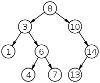

```c
typedef struct node
{
        int n;
        struct node* left;
        struct node* right;
}
node;

bool search(int n, node* tree)
{
        if (tree == NULL)
        {
                return false;
        }
        else if (n < tree->n)
        {
                return search(n, tree->left)
        }
        else if (n > tree->n)
        {
                return search(n, tree->right)
        }
        else
        {
                return true;
        }
}
```

# Compression

Everything can be compressed, especially images and video. But what about text!!?

In ASCII, each letter is 8 bits, even for the less popular letters. Why not encode popular letters as smaller values?

This exists: morse code. However, this isn’t efficient; it’s ambiguous because you need spaces/gaps.

```
    (1.0)
   /    \
0 /      \ 1
 /        \
(0.55)       \
/    \        \
0 /      \ 1      \
/        \        \
(0.35)       \        \
/    \        \        \
0 /      \ 1      \        \
/        \        \        \
(0.2)        \        \        \
/   \         \        \        \
0 /     \ 1       \        \        \
/       \         \        \        \
(0.1)     (0.1)     (0.15)    (0.2)    (0.45)
B         C         D         A        E
```

## Hash Tables

A hash table is just a table of values; look at input and categorize it.

**linear probing**

one value for the hash table; linear

**separate chaining**

each value in the table is a linked list!

# Tries

A trie (retrieval) is a tree. Each child is an array however.

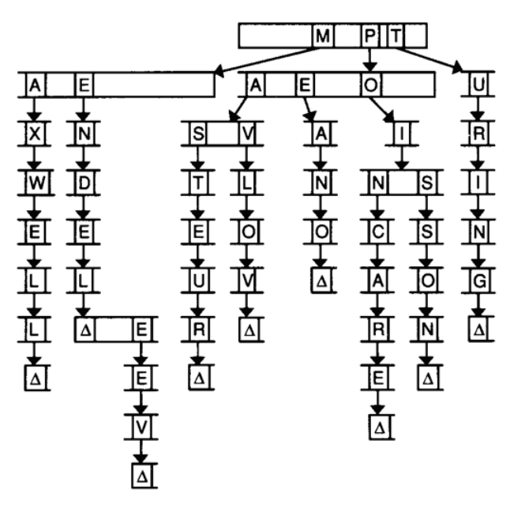

This is $O(1)$! The search time is proportional to length of the input. This is *the holy grail of running time*.